# Bluefish

Abigail Tyrell

30 Nov 2020

This is a preliminary report of `assessmentdata` and `survdat` data. This report is pulling information on all Northeast Bluefish stocks.

# 1 Methods

## 1.1 General methods

Latitude and longitude ranges were compiled from NOAA/EDAB ECSA [seasonal species strata](https://github.com/NOAA-EDAB/ECSA/blob/master/data/seasonal_stock_strata.csv) and [Bottom Trawl Survey (BTS) shapefiles](https://github.com/NOAA-EDAB/ECSA/tree/master/data/strata_shapefiles). The coordinate system is WGS84.

All continuous temporal data were plotted against time. If there were 30 or more years of data, a geom_gls regression line was fit (yellow = significant increase; purple = significant decrease; no line = no significant trend). If there were fewer than 30 years of data, no regression was fit.

## 1.2 `assessmentdata` methods

Stock assessment and data quality information were compiled into a summary table.

B/Bmsy was classified as “DANGER” if it was below 1 and “GOOD” if it was above 1.

F/Fmsy was classified as “DANGER” if it was above 1 and “GOOD” if it was below 1.

## 1.3 `survdat` methods

`survdat` data with zero abundance were not included in this analysis. Abundance and biomass were summed for each year and season. All other metrics were averaged for each year and season. The tables show summary statistics for the entire time series and for the most recent 5 years in the time series.

# 2 Results

## 2.1 Latitude and longitude

Latitude and longitude ranges were compiled from NOAA/EDAB ECSA [seasonal species strata](https://github.com/NOAA-EDAB/ECSA/blob/master/data/seasonal_stock_strata.csv) and [Bottom Trawl Survey (BTS) shapefiles](https://github.com/NOAA-EDAB/ECSA/tree/master/data/strata_shapefiles). The coordinate system is WGS84.

[output not shown]

## 2.2 Stock assessment and data quality information

Stock assessment and data quality information were pulled from `assessmentdata::stockAssessmentSummary`.

| Species | Region | Assessment Year | Last Data Year | Biological Data Rating (2019) | Biological Data Rating (before 2019) | Size Data Rating | Ecosystem Linkage Data Rating | FSSI status | Review Result |
| --- | --- | --- | --- | --- | --- | --- | --- | --- | --- |

## 2.3 B/Bmsy

B/Bmsy data were pulled from `assessmentdata::stockAssessmentSummary`.

The most recent status of B/Bmsy is: UNKNOWN

```
## [1] "NO DATA"
```

## 2.4 F/Fmsy

F/Fmsy data were pulled from `assessmentdata::stockAssessmentSummary`.

The most recent status of F/Fmsy is: UNKNOWN

```
## [1] "NO DATA"
```

## 2.5 Recruitment

Recruitment data were pulled from `assessmentdata::stockAssessmentData`.

### 2.5.1 Past 20 years

```
## [1] "NO DATA"
```

### 2.5.2 All years

```
## [1] "NO DATA"
```

## 2.6 Temperature

### 2.6.1 Surface temperature

Surface temperature data were pulled from `survdat`.

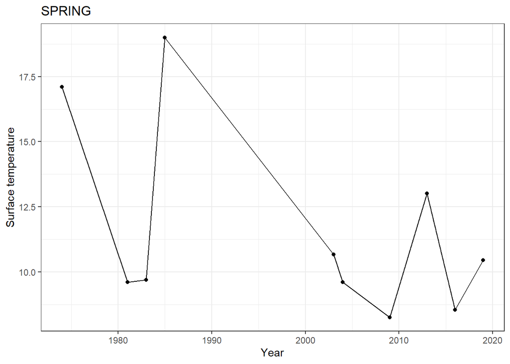

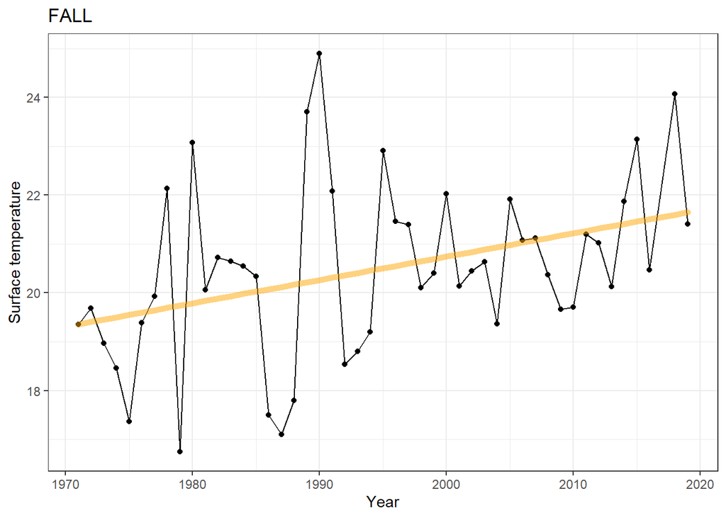

| SEASON | YEARS | N_YEARS | MEAN | SD | MIN | MAX |
| --- | --- | --- | --- | --- | --- | --- |
| SPRING | 1974 - 2019 | 10 | 11.6 | 3.67 | 8.26 | 19 |
| SPRING | 2016 - 2019 | 2 | 9.5 | 1.34 | 8.55 | 10.45 |
| FALL | 1971 - 2019 | 48 | 20.48 | 1.79 | 16.75 | 24.9 |
| FALL | 2015 - 2019 | 4 | 22.27 | 1.63 | 20.47 | 24.07 |

### 2.6.2 Bottom temperature

Bottom temperature data were pulled from `survdat`.

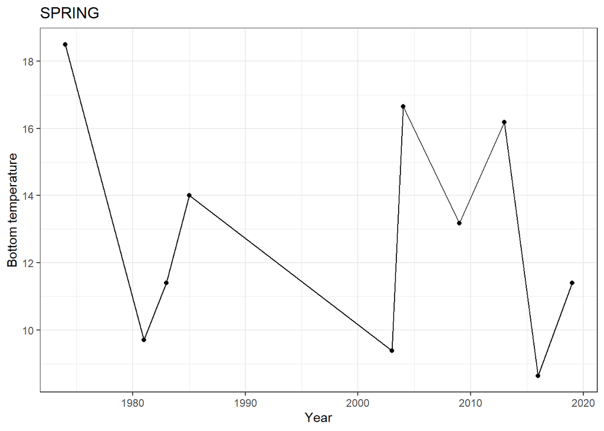

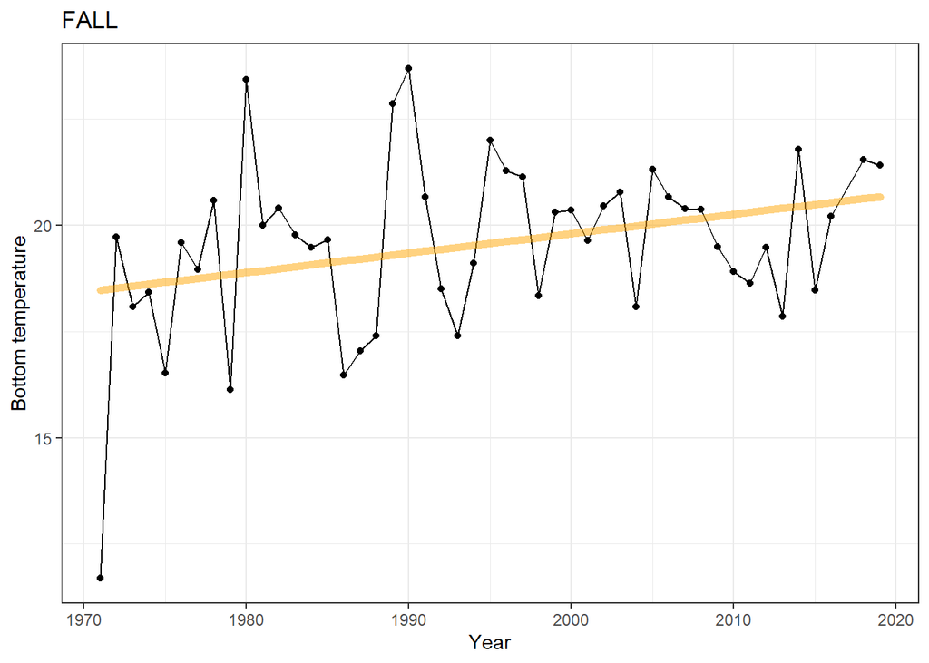

| SEASON | YEARS | N_YEARS | MEAN | SD | MIN | MAX |
| --- | --- | --- | --- | --- | --- | --- |
| SPRING | 1974 - 2019 | 10 | 12.9 | 3.38 | 8.64 | 18.5 |
| SPRING | 2016 - 2019 | 2 | 10.02 | 1.95 | 8.64 | 11.4 |
| FALL | 1971 - 2019 | 48 | 19.56 | 2.07 | 11.7 | 23.7 |
| FALL | 2015 - 2019 | 4 | 20.41 | 1.42 | 18.48 | 21.55 |

## 2.7 Salinity

### 2.7.1 Surface salinity

Surface salinity data were pulled from `survdat`.

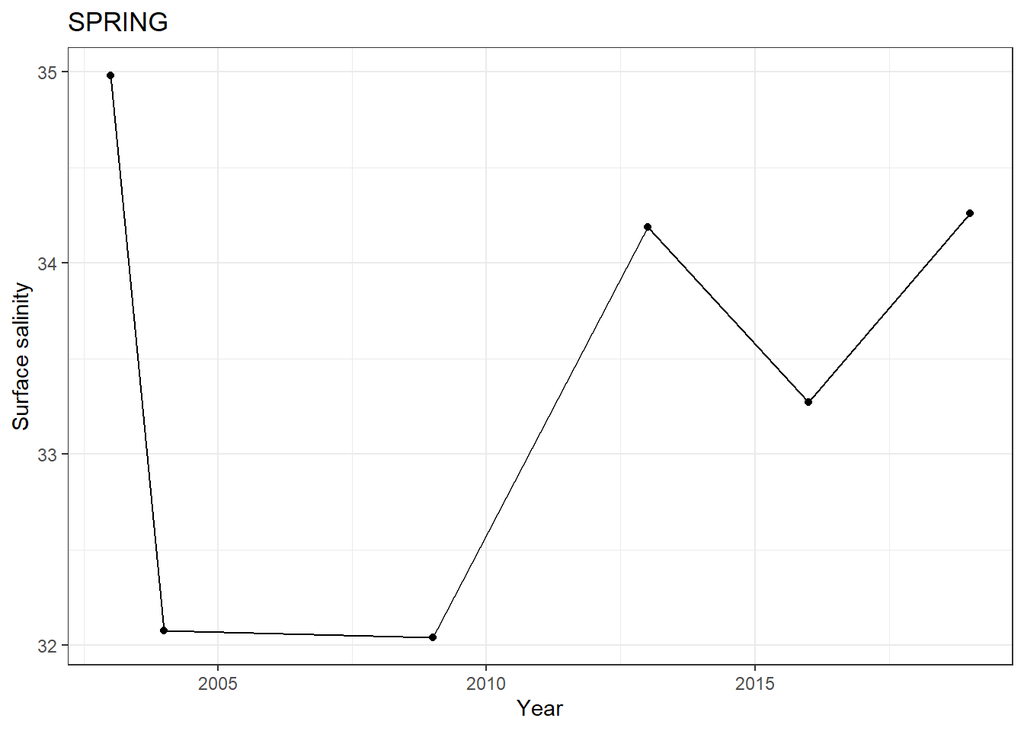

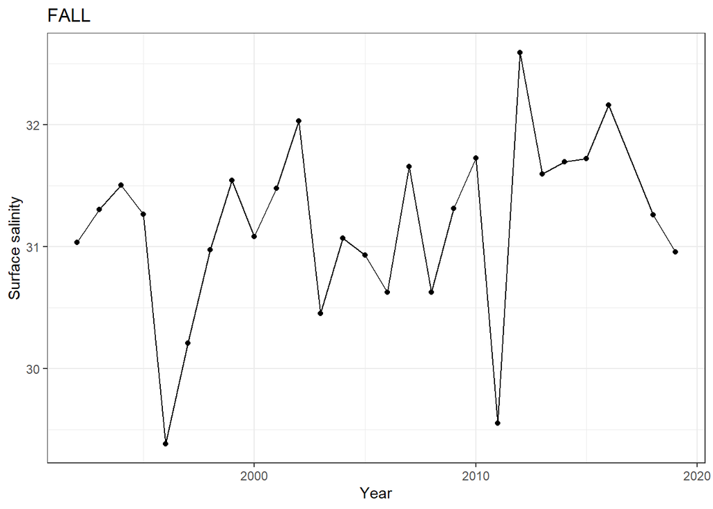

| SEASON | YEARS | N_YEARS | MEAN | SD | MIN | MAX |
| --- | --- | --- | --- | --- | --- | --- |
| SPRING | 2003 - 2019 | 6 | 33.47 | 1.22 | 32.04 | 34.98 |
| SPRING | 2016 - 2019 | 2 | 33.77 | 0.7 | 33.27 | 34.26 |
| FALL | 1992 - 2019 | 27 | 31.18 | 0.72 | 29.38 | 32.59 |
| FALL | 2015 - 2019 | 4 | 31.52 | 0.53 | 30.95 | 32.16 |

### 2.7.2 Bottom salinity

Bottom salinity data were pulled from `survdat`.

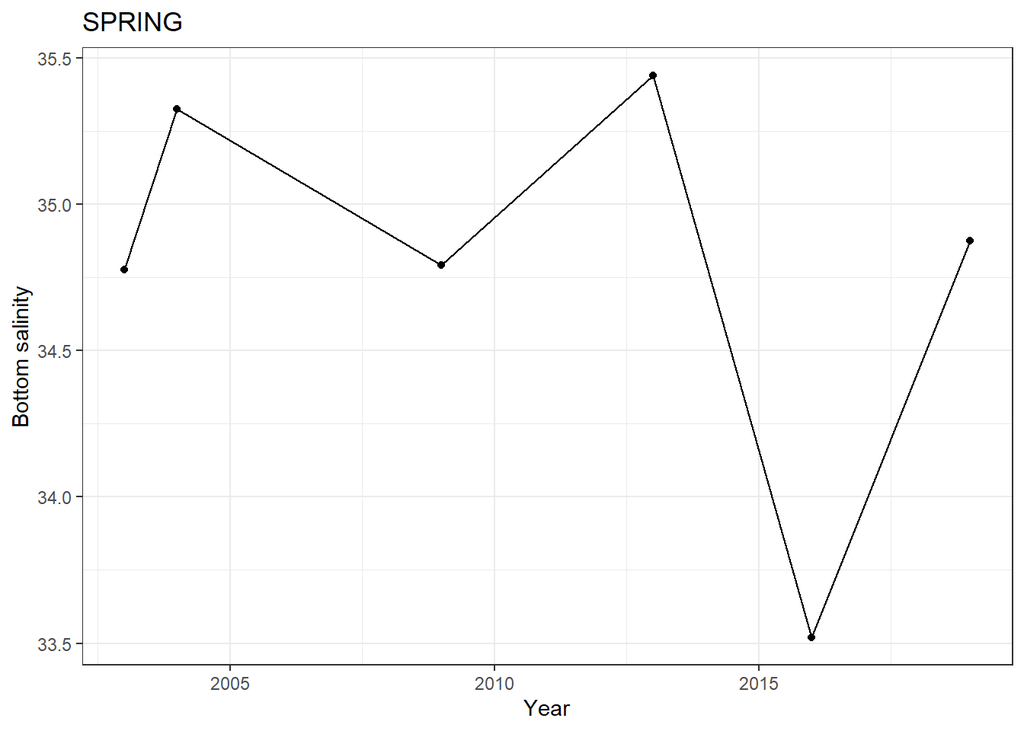

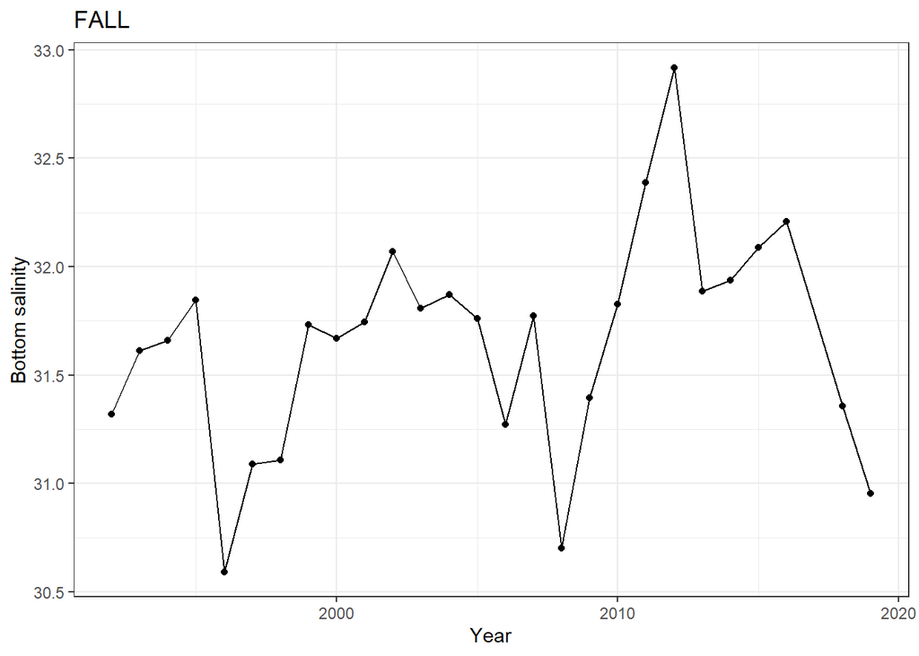

| SEASON | YEARS | N_YEARS | MEAN | SD | MIN | MAX |
| --- | --- | --- | --- | --- | --- | --- |
| SPRING | 2003 - 2019 | 6 | 34.79 | 0.68 | 33.52 | 35.44 |
| SPRING | 2016 - 2019 | 2 | 34.2 | 0.96 | 33.52 | 34.87 |
| FALL | 1992 - 2019 | 27 | 31.65 | 0.51 | 30.59 | 32.92 |
| FALL | 2015 - 2019 | 4 | 31.65 | 0.6 | 30.95 | 32.21 |

## 2.8 Abundance

Abundance data were pulled from `survdat`.

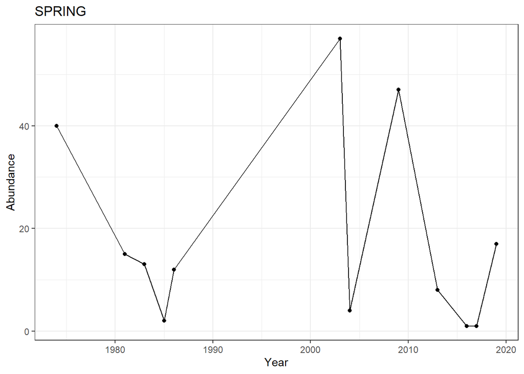

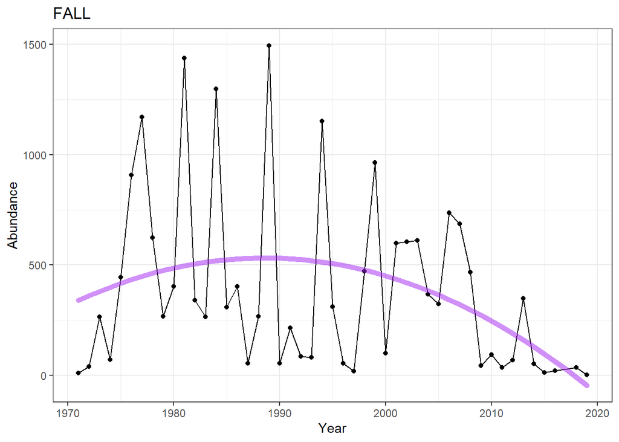

| SEASON | YEARS | N_YEARS | MEAN | SD | MIN | MAX |
| --- | --- | --- | --- | --- | --- | --- |
| SPRING | 1974 - 2019 | 12 | 18.08 | 19.18 | 1 | 57 |
| SPRING | 2016 - 2019 | 3 | 6.33 | 9.24 | 1 | 17 |
| FALL | 1971 - 2019 | 48 | 389.54 | 404.26 | 3 | 1495 |
| FALL | 2015 - 2019 | 4 | 18 | 13.52 | 3 | 35 |

## 2.9 Biomass

Biomass data were pulled from `survdat`.

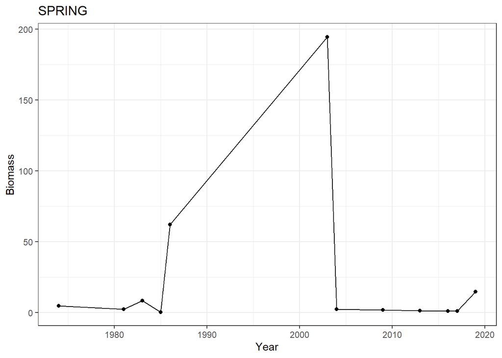

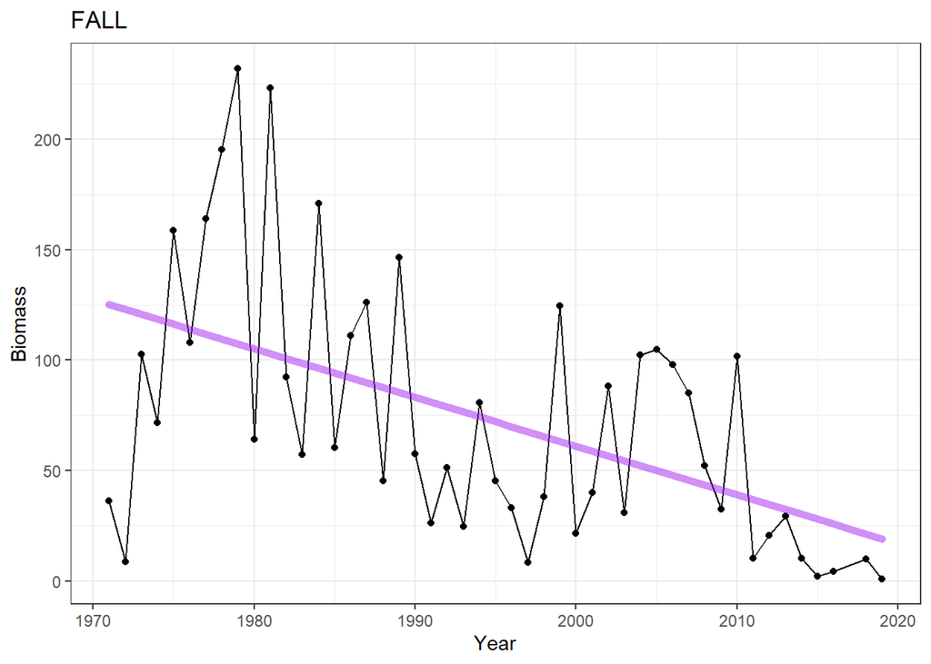

| SEASON | YEARS | N_YEARS | MEAN | SD | MIN | MAX |
| --- | --- | --- | --- | --- | --- | --- |
| SPRING | 1974 - 2019 | 12 | 24.52 | 56.27 | 0.3 | 194.6 |
| SPRING | 2016 - 2019 | 3 | 5.56 | 7.89 | 0.93 | 14.68 |
| FALL | 1971 - 2019 | 48 | 73.16 | 59.3 | 1.04 | 232.1 |
| FALL | 2015 - 2019 | 4 | 4.41 | 4.03 | 1.04 | 10.08 |

## 2.10 Length

Length data were pulled from `survdat`.

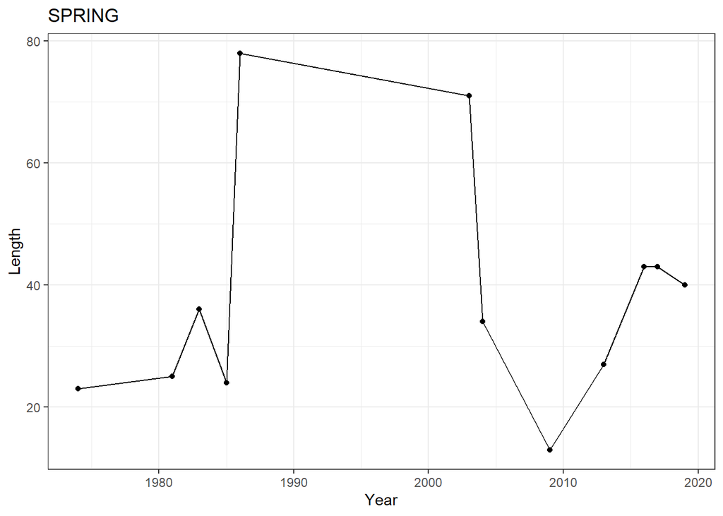

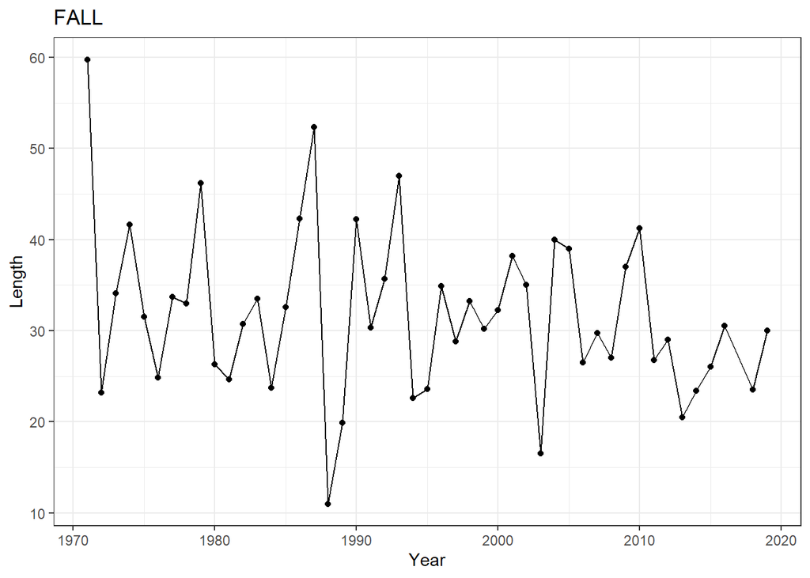

| SEASON | YEARS | N_YEARS | MEAN | SD | MIN | MAX |
| --- | --- | --- | --- | --- | --- | --- |
| SPRING | 1974 - 2019 | 12 | 38.08 | 19.3 | 13 | 78 |
| SPRING | 2016 - 2019 | 3 | 42 | 1.73 | 40 | 43 |
| FALL | 1971 - 2019 | 48 | 31.78 | 9.13 | 11 | 59.75 |
| FALL | 2015 - 2019 | 4 | 27.5 | 3.34 | 23.5 | 30.5 |